# Part 4 Depth From Video

In order to compute depth from video, depth initialization and bundle optimization are performed. Depth initialization is carried out for a set of 20 frames. For each frame under consideration, a set of 30 neighbouring frames are utilized for commputation of initial dempth maps wherein 15 are taken from the left of the present frame and 15 are taken from the right. Bundle optimization has been performed for a set of 5 frames. It can be seen that bundle optimization can help reduce the noise obtained in the depth maps computed from depth map initialization process. It can be seen that the results are not very proper dur to memory error, kernel error and installation issues. As a result of these issues, the orginal size of the image could not be used and had to be downscaled to a smaller size to avoid memory errors. However, with reduction in the size, the output does not come out as good as expected.

```python
#from pygco import cut_simple
import numpy as np
import cv2
import matplotlib.pyplot as plt
import gco
import os
os.add_dll_directory('C:/MinGW/bin')
from scipy.sparse import csr_matrix
```

```python
f = open ('C:/Users/Varshini/AppData/Local/Programs/Python/Python38-32/Road/cameras.txt' , 'r')
l = []
l = [ line.split() for line in f if len(line.split())!=0]
print(l)

matrices=[]
for row in l:
    matrices.append([np.float32(val) for val in row])
```

```
[['141'], ['1221.2270770', '0.0000000', '479.5000000'], ['0.0000000', '1221.2270770', '269.5000000'], ['0.0000000', '0.0000000', '1.0000000'], ['1.0000000000', '0.0000000000', '0.0000000000'], ['0.0000000000', '1.0000000000', '0.0000000000'], ['0.0000000000', '0.0000000000', '1.0000000000'], ['0.000…
```

```python
dmin = 0
dmax = 0.01
step = 0.0001
disparity=np.arange(dmin,dmax+step,step)
epsilon=50
```

```python
disparity
```

```
array([0.    , 0.0001, 0.0002, 0.0003, 0.0004, 0.0005, 0.0006, 0.0007,
       0.0008, 0.0009, 0.001 , 0.0011, 0.0012, 0.0013, 0.0014, 0.0015,
       0.0016, 0.0017, 0.0018, 0.0019, 0.002 , 0.0021, 0.0022, 0.0023,
       0.0024, 0.0025, 0.0026, 0.0027, 0.0028, 0.0029, 0.003 , 0.0031,
       0.0032, 0.0033, 0.0034, 0.0035, 0.0036, 0.0037, 0.0038, 0.0039,
       0.004 , 0.0041, 0.0042, 0.0043, 0.0044, 0.0045, 0.0046, 0.0047,
       0.0048, 0.0049, 0.005 , 0.0051, 0.0052, 0.0053, 0.0054, 0.0055,
       0.0056, 0.0057, 0.0058, 0.0059, 0.006 , 0.0061, 0.0062, 0.0063,
       0.0064, 0.0065, 0.0066, 0.0067, 0.0068, 0.0069, 0.007 , 0.0071,
       0.0072, 0.0073, 0.0074, 0.0075, 0.0076, 0.0077, 0.0078, 0.0079,
       0.008 , 0.0081, 0.0082, 0.0083, 0.0084, 0.0085, 0.0086, 0.0087,
       0.0088, 0.0089, 0.009 , 0.0091, 0.0092, 0.0093, 0.0094, 0.0095,
       0.0096, 0.0097, 0.0098, 0.0099, 0.01  ])
```

```python
# % prior term - set labelcost
eta = 0.05 * (max(disparity) - min(disparity))
[a, b] = np.meshgrid(disparity,disparity)
rho = np.minimum(abs(a - b), eta)
labelcost = rho
```

```python
num_neighbour = 30
```

```python
img_files=os.listdir('C:/Users/Varshini/AppData/Local/Programs/Python/Python38-32/Road/src')
```

```python
for i in img_files:
    img=plt.imread('C:/Users/Varshini/AppData/Local/Programs/Python/Python38-32/Road/src/'+i)
    img=cv2.resize(img,(480,270))
    cv2.imwrite('C:/Users/Varshini/'+i+'.jpg',cv2.cvtColor(img, cv2.COLOR_BGR2RGB))
```

```python
[H, W] = img1.shape[0:2]
```

```python
nx=4*np.ones([H,W])
#nx1=nx.copy()
nx[[0,-1], :] = nx[[0,-1], :] - 1
nx[:,[0,-1]] = nx[:,[0,-1]] - 1
#nx[:, 0:1] = nx[:,0:1] - 1
#nx_t=nx.T
nx_t1=nx.flatten()
```

```python
w_s = 2/ (disparity[-1] - disparity[0])
```

```python
import numpy.matlib
sigma_c = 10
row = np.matlib.repmat(np.arange(0,H), W, 1).T
row_flat=row.flatten().T
col = np.matlib.repmat(np.arange(0,W).T, 1, H)
col_flat=col.flatten().T
```

```python
col = np.matlib.repmat(np.arange(0,W), H, 1).T
col
```

```
array([[  0,   0,   0, ...,   0,   0,   0],
       [  1,   1,   1, ...,   1,   1,   1],
       [  2,   2,   2, ...,   2,   2,   2],
       ...,
       [317, 317, 317, ..., 317, 317, 317],
       [318, 318, 318, ..., 318, 318, 318],
       [319, 319, 319, ..., 319, 319, 319]])
```

```python
img1_coord=np.vstack([col_flat,row_flat]).astype(np.int32)
img1_coord.shape
```

```
(2, 57600)
```

```python
img1_coord_homo=np.vstack([col_flat,row_flat,np.ones(H*W)]).astype(np.int32)
```

```python
img1_coord_homo[1]
```

```
array([  0,   0,   0, ..., 179, 179, 179])
```

```python
img1_pixel=img1[img1_coord_homo[1],img1_coord_homo[0]]
img1_pixel
```

```
array([[247, 255, 255],
       [247, 255, 255],
       [247, 255, 255],
       ...,
       [142, 144, 139],
       [147, 149, 144],
       [147, 149, 144]], dtype=uint8)
```

Depth Initialization:

```python
labels_frames=[]
for img1_idx in range(0,20):
    img1=plt.imread('C:/Users/Varshini/AppData/Local/Programs/Python/Python38-32/Road/src/'+img_files[img1_idx])
    img1=cv2.resize(img1,(320,180))
    #camera matrices
    K1=np.array(matrices[img1_idx *7+ 1 : img1_idx *7+ 4 ])
    R1=np.array(matrices[img1_idx *7+ 4 : img1_idx *7+ 7 ])
    T1=np.array(matrices[img1_idx *7+ 7])

    #construct graph for weights
    index_arr=np.arange(0,H*W)
    index_arr1=index_arr.reshape(H,W)
    up= index_arr1[0:-1, :].astype(np.int32)
    down=index_arr1[1:,:].astype(np.int32)
    left= index_arr1[:,0:-1].astype(np.int32)
    right=index_arr1[:,1:].astype(np.int32)
    source=np.concatenate((up.flatten(), down.flatten(), left.flatten(), right.flatten()),axis=0)
    target=np.concatenate((down.flatten(), up.flatten(), right.flatten(), left.flatten()),axis=0)
    r = img1[:, :, 0]
    r = r.flatten()
    g = img1[:, :, 1]
    g = g.flatten()
    b = img1[:, :, 2]
    b = b.flatten()
    weights = np.square(r[source] - r[target]) +  np.square(g[source] - g[target]) + np.square(b[source] - b[target])
    weights1 = np.divide(1 , (np.sqrt((weights)) + epsilon))
    pairwise = csr_matrix((weights1,(source, target)))
    non_zero_source_ind=pairwise.nonzero()[1]
    denominator = np.sum(pairwise,axis=0)
    u_lambda = nx_t1 / denominator

    w_s = 10/ (disparity[-1] - disparity[0])
    lambda_val = np.multiply(w_s ,np.multiply (np.array(u_lambda)[0][non_zero_source_ind] , weights1))

    cost_v=lambda_val[0:W*(H-1)].reshape(H-1,W)
    cost_h=lambda_val[2*W*(H-1):2*W*(H-1)+H*(W-1)].reshape(H,W-1)

    #data term

    img1_pixel=img1[img1_coord_homo[1],img1_coord_homo[0]]
    img2_idx_range_vals = np.arange(img1_idx - num_neighbour/2,img1_idx + num_neighbour/2 +1,1).astype(np.int32)
    img2_range=[i for i in img2_idx_range_vals if (i>=0 and i!=img1_idx and i<140) ]
    differences=np.zeros((H,W,len(disparity)))
    #differences=np.zeros((H,W,len(disparity)))
    for i in range(0,len(img2_range)):
        img2_idx = img2_range[i]
        K2=np.array(matrices[img2_idx *7+ 1 : img2_idx *7+ 4 ])
        R2=np.array(matrices[img2_idx *7+ 4 : img2_idx *7+ 7 ])
        T2=np.array(matrices[img2_idx *7+ 7])
        img2=plt.imread('C:/Users/Varshini/AppData/Local/Programs/Python/Python38-32/Road/src/'+img_files[img2_idx])
        img2=cv2.resize(img2,(320,180))
        pc = np.zeros((H,W,len(disparity)))
        for d in range(len(disparity)):

        #for d in  np.arange(0,max_disp,0.00005):
        #for d in np.arange(0,0.01,0.005):
            #img1_coord_reshape = np.reshape(img1_coord_homo, [3,-1])

            #d=np.reshape(disparity[i],[1,-1])
            #print(d)
            #depth = (T-T1).T * d
        #     img2_coord_homo=((K1@R1.T)@(R@np.linalg.inv(K))@img1_coord_homo)+ (disparity[d]*(K1@R1.T)@(T-T1).T)
            #img2_coord_homo=np.dot(np.dot(np.dot(K1,R1.T),np.dot(R,np.asmatrix(K).I)),img1_coord_homo) + (disparity[d]*np.dot((K1*R1.T),(T-T1).T))
            mult1=np.dot(K2,R2.T)
            mult2=np.dot(mult1,R1)
            mult3=np.dot(mult2,np.linalg.inv(K1))
            img2_coord_homo=np.dot(mult3,img1_coord_homo)+(disparity[d]*np.dot(np.dot(K2,R2.T),(T1-T2).T)).reshape(3,1)

        #     img2_coord_homo=np.dot(np.dot(np.dot(np.dot(K1,R1.T),R),np.linalg.inv(K)),img1_coord_homo)
        #     img2_coord_homo2=disparity[d]*np.dot(np.dot(K1,R1.T),(T-T1))
        #     img2_coord_homo+=img2_coord_homo2
            #img2_coord_homo=(K2 @ R2.T @ R1@np.linalg.inv(K) @ img1_coord_homo) + d * K2 @ R2.T @ (T1 - T2).T
            img2_coord= img2_coord_homo/ img2_coord_homo[2, :][None,:]
            img2_coord = np.round(img2_coord_homo[0:2,:]).astype(np.int32)
        #     img2_pixel=[]
            img2_coord[0][img2_coord[0]>W-1]=W-1
            img2_coord[1][img2_coord[1]>H-1]=H-1

            img2_pixel=img2[img2_coord[1],img2_coord[0]]
        #     for k in range(img2_coord.shape[1]):
        #         (y,x)=img2_coord[:,k]
        #         if y<W and x<H and y>=0 and x>=0:
        #             img2_pixel.append(img2[x,y])
        #         else:
        #             img2_pixel.append([0,0,0])
            #if disp == 0:

            #    diff = np.sqrt(np.sum((img1 - img2) ** 2, axis=2))
            #else:
            #diff = np.sqrt(np.sum((img1[:, 2 * (disp+1):, :] - img2[:, :-2 * (disp+1), :]) **
            #            2, axis=2))
            #diff=sigma_c / (sigma_c + np.sqrt(np.sum(np.square(np.array(img1_pixel).reshape([H,W,3])-np.array(img2_pixel).reshape([H,W,3]),dtype=np.float32), axis=-1)))
            #diff=sigma_c / (sigma_c + np.sqrt(np.sum(np.square(img1-img2_proj,dtype=np.float32), axis=-1)))
            #diff=sigma_c / (sigma_c + np.sqrt(np.sum(np.square(np.array(img1_pixel)-np.array(img2_pixel),dtype=np.float32), axis=-1)))
            l2 = np.sqrt(np.sum((img1_pixel-img2_pixel)**2,axis=1))
            diff=sigma_c/(sigma_c+l2)
            pc[:,:,d]=diff.reshape(H,W)
        differences = differences + pc
    differences=1-differences/np.max(differences)
    labels= gco.cut_grid_graph(
     differences,rho,
    cost_v,
     cost_h,
     n_iter=-1,
    algorithm='swap'
    )

    #numpy.save('init_frame_'+str(img1_idx)+'.npy', labels, allow_pickle=True, fix_imports=True)
    labels_frames.append(labels)

    #cv2.imwrite('depth_map_frame_'+str(img2_idx)+'jpg',labels.reshape(H,W))
```

```
0 57598 57599 1 57600
0 57598 57599 1 57600
0 57598 57599 1 57600
0 57598 57599 1 57600
0 57598 57599 1 57600
0 57598 57599 1 57600
0 57598 57599 1 57600
0 57598 57599 1 57600
0 57598 57599 1 57600
0 57598 57599 1 57600
0 57598 57599 1 57600
0 57598 57599 1 57600
0 57598 57599 1 57600
0 57598 57599 1 57600
0 57598 57599 1 57600
0 57598 57599 1 57600
0 57598 57599 1 57600
0 57598 57599 1 57600
0 57598 57599 1 57600
0 57598 57599 1 57600
```

```python
labels_frames
```

```
[array([6, 5, 2, ..., 0, 0, 1], dtype=int32),
 array([ 9,  8,  8, ..., 39, 38, 39], dtype=int32),
 array([ 3,  2,  1, ..., 37, 37, 37], dtype=int32),
 array([ 5,  4,  3, ..., 51, 50, 50], dtype=int32),
 array([3, 2, 3, ..., 1, 2, 2], dtype=int32),
 array([2, 3, 3, ..., 1, 1, 0], dtype=int32),
 array([ 2,  3,  2, ..., 54, 52, 54], dtype=int32),
 array([ 0,  0,  1, ..., 54, 53, 53], dtype=int32),
 array([ 0,  0,  0, ..., 98, 98, 96], dtype=int32),
 array([ 1,  0,  0, ..., 43, 44, 46], dtype=int32),
 array([0, 1, 0, ..., 1, 0, 1], dtype=int32),
 array([ 1,  0,  0, ..., 64, 65, 66], dtype=int32),
 array([ 0,  0,  1, ..., 45, 47, 48], dtype=int32),
 array([ 1,  2,  3, ..., 84, 83, 83], dtype=int32),
 array([ 1,  2,  3, ..., 45, 44, 44], dtype=int32),
 array([ 0,  1,  2, ..., 35, 35, 35], dtype=int32),
 array([ 0,  1,  1, ..., 55, 57, 59], dtype=int32),
 array([0, 1, 1, ..., 2, 1, 0], dtype=int32),
 array([0, 0, 0, ..., 1, 2, 3], dtype=int32),
 array([ 0,  0,  0, ..., 38, 39, 39], dtype=int32)]
```

```python
np.save('label_frames.npy',np.array(labels_frames))
```

```python
labels_frames=np.load('label_frames.npy')
labels_frames[0]
```

```
array([6, 5, 2, ..., 0, 0, 1])
```

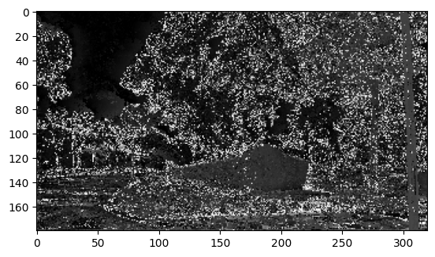

```python
plt.imshow(labels_frames[19
].reshape(H,W),cmap='gray')
```

```python
disparity[labels]
```

```
array([0.0003, 0.0002, 0.0003, ..., 0.0001, 0.0002, 0.0002])
```

```python
labels
```

```
array([4, 3, 4, ..., 2, 3, 3], dtype=int32)
```

Bundle Optimization:

```python
labels_frames_bo=[]
for img1_idx in range(0,5):
    img1=plt.imread('C:/Users/Varshini/AppData/Local/Programs/Python/Python38-32/Road/src/'+img_files[img1_idx])
    img1=cv2.resize(img1,(480,270))
    #camera matrices
    K1=np.array(matrices[img1_idx *7+ 1 : img1_idx *7+ 4 ])
    R1=np.array(matrices[img1_idx *7+ 4 : img1_idx *7+ 7 ])
    T1=np.array(matrices[img1_idx *7+ 7])

    #construct graph for weights
    index_arr=np.arange(0,H*W)
    index_arr1=index_arr.reshape(H,W)
    up= index_arr1[0:-1, :].astype(np.int32)
    down=index_arr1[1:,:].astype(np.int32)
    left= index_arr1[:,0:-1].astype(np.int32)
    right=index_arr1[:,1:].astype(np.int32)
    source=np.concatenate((up.flatten(), down.flatten(), left.flatten(), right.flatten()),axis=0)
    target=np.concatenate((down.flatten(), up.flatten(), right.flatten(), left.flatten()),axis=0)
    r = img1[:, :, 0]
    r = r.flatten()
    g = img1[:, :, 1]
    g = g.flatten()
    b = img1[:, :, 2]
    b = b.flatten()
    weights = np.square(r[source] - r[target]) +  np.square(g[source] - g[target]) + np.square(b[source] - b[target])
    weights1 = np.divide(1 , (np.sqrt((weights)) + epsilon))
    pairwise = csr_matrix((weights1,(source, target)))
    non_zero_source_ind=pairwise.nonzero()[1]
    denominator = np.sum(pairwise,axis=0)
    u_lambda = nx_t1 / denominator

    w_s = 10/ (disparity[-1] - disparity[0])
    lambda_val = np.multiply(w_s ,np.multiply (np.array(u_lambda)[0][non_zero_source_ind] , weights1))

    cost_v=lambda_val[0:W*(H-1)].reshape(H-1,W)
    cost_h=lambda_val[2*W*(H-1):2*W*(H-1)+H*(W-1)].reshape(H,W-1)

    #data term

    img1_pixel=img1[img1_coord_homo[1],img1_coord_homo[0]]
    img2_idx_range_vals = np.arange(img1_idx - num_neighbour/2,img1_idx + num_neighbour/2 +1,1).astype(np.int32)
    img2_range=[i for i in img2_idx_range_vals if (i>=0 and i!=img1_idx and i<140) ]
    differences=np.zeros((H,W,len(disparity)))
    #differences=np.zeros((H,W,len(disparity)))
    for i in range(0,len(img2_range)):
        img2_idx = img2_range[i]
        K2=np.array(matrices[img2_idx *7+ 1 : img2_idx *7+ 4 ])
        R2=np.array(matrices[img2_idx *7+ 4 : img2_idx *7+ 7 ])
        T2=np.array(matrices[img2_idx *7+ 7])
        img2=plt.imread('C:/Users/Varshini/AppData/Local/Programs/Python/Python38-32/Road/src/'+img_files[img2_idx])
        img2=cv2.resize(img2,(480,270))
        pc = np.zeros((H,W,len(disparity)))
        pv=  np.zeros((H,W,len(disparity)))
        for d in range(len(disparity)):

        #for d in  np.arange(0,max_disp,0.00005):
        #for d in np.arange(0,0.01,0.005):
            #img1_coord_reshape = np.reshape(img1_coord_homo, [3,-1])

            #d=np.reshape(disparity[i],[1,-1])
            #print(d)
            #depth = (T-T1).T * d
        #     img2_coord_homo=((K1@R1.T)@(R@np.linalg.inv(K))@img1_coord_homo)+ (disparity[d]*(K1@R1.T)@(T-T1).T)
            #img2_coord_homo=np.dot(np.dot(np.dot(K1,R1.T),np.dot(R,np.asmatrix(K).I)),img1_coord_homo) + (disparity[d]*np.dot((K1*R1.T),(T-T1).T))
            mult1=np.dot(K2,R2.T)
            mult2=np.dot(mult1,R1)
            mult3=np.dot(mult2,np.linalg.inv(K1))
            img2_coord_homo=np.dot(mult3,img1_coord_homo)+(disparity[d]*np.dot(np.dot(K2,R2.T),(T1-T2).T)).reshape(3,1)

        #     img2_coord_homo=np.dot(np.dot(np.dot(np.dot(K1,R1.T),R),np.linalg.inv(K)),img1_coord_homo)
        #     img2_coord_homo2=disparity[d]*np.dot(np.dot(K1,R1.T),(T-T1))
        #     img2_coord_homo+=img2_coord_homo2
            #img2_coord_homo=(K2 @ R2.T @ R1@np.linalg.inv(K) @ img1_coord_homo) + d * K2 @ R2.T @ (T1 - T2).T
            img2_coord= img2_coord_homo/ img2_coord_homo[2, :][None,:]
            img2_coord = np.round(img2_coord[0:2,:]).astype(np.int32)
        #     img2_pixel=[]
            img2_coord[0][img2_coord[0]>W-1]=W-1
            img2_coord[1][img2_coord[1]>H-1]=H-1
            img2_coord[0][img2_coord[0]<0]=0
            img2_coord[1][img2_coord[1]<0]=0

            img2_pixel=img2[img2_coord[1],img2_coord[0]]
        #     for k in range(img2_coord.shape[1]):
        #         (y,x)=img2_coord[:,k]
        #         if y<W and x<H and y>=0 and x>=0:
        #             img2_pixel.append(img2[x,y])
        #         else:
        #             img2_pixel.append([0,0,0])
            #if disp == 0:

            #    diff = np.sqrt(np.sum((img1 - img2) ** 2, axis=2))
            #else:
            #diff = np.sqrt(np.sum((img1[:, 2 * (disp+1):, :] - img2[:, :-2 * (disp+1), :]) **
            #            2, axis=2))
            #diff=sigma_c / (sigma_c + np.sqrt(np.sum(np.square(np.array(img1_pixel).reshape([H,W,3])-np.array(img2_pixel).reshape([H,W,3]),dtype=np.float32), axis=-1)))
            #diff=sigma_c / (sigma_c + np.sqrt(np.sum(np.square(img1-img2_proj,dtype=np.float32), axis=-1)))
            #diff=sigma_c / (sigma_c + np.sqrt(np.sum(np.square(np.array(img1_pixel)-np.array(img2_pixel),dtype=np.float32), axis=-1)))
            l2 = np.sqrt(np.sum((img1_pixel-img2_pixel)**2,axis=1))
            diff=sigma_c/(sigma_c+l2)
            pc[:,:,d]=diff.reshape(H,W)

            label_vals=labels_frames[img2_idx]
            disparity_img2=disparity[label_vals]
            cols=img2_coord[0]
            rows=img2_coord[1]
            img2_coord_idx=np.ravel_multi_index([cols, rows], (W,H), order='F')
            img2_project_homo = np.vstack([img2_coord, np.ones([1, H*W])])
            mult4=np.dot(K1,R1.T)
            mult5=np.dot(mult1,R2)
            mult6=np.dot(mult2,np.linalg.inv(K2))
            img1_project_homo=np.dot(mult6,img2_project_homo)+np.multiply((np.dot(np.dot(K1,R1.T),(T2-T1).T)).reshape(3,1) , disparity_img2[img2_coord_idx].reshape(len(disparity_img2[img2_coord_idx]),1).T)
            img1_project= img1_project_homo/ img1_project_homo[2, :][None,:]
            img1_project=np.round(img1_project[0:2,:]).astype(np.int32)
            dist=np.sum((img1_coord - img1_project)**2,axis=0)
            sigma_d = 2.5
            pv[:,:,d] = (np.exp(-dist / (2*sigma_d**2))).reshape([H,W])





        differences = differences + np.multiply(pc,pv)

    differences=1-differences/np.max(differences)
    labels= gco.cut_grid_graph(
     differences,rho,
    cost_v,
     cost_h,
     n_iter=-1,
    algorithm='swap'
    )



    #numpy.save('init_frame_'+str(img1_idx)+'.npy', labels, allow_pickle=True, fix_imports=True)
    labels_frames_bo.append(labels)

    #cv2.imwrite('depth_map_frame_'+str(img2_idx)+'jpg',labels.reshape(H,W))
```

```
0 57598 57599 1 57600
0 57598 57599 1 57600
0 57598 57599 1 57600
0 57598 57599 1 57600
0 57598 57599 1 57600
```

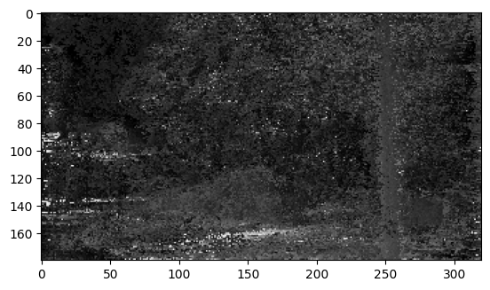

```python
plt.imshow(labels.reshape([H,W]),cmap='gray')
```

```python
x, y = np.ogrid[:101, :101]
one_d_topology = np.abs(x - y).astype(np.int32).copy("C")
```

```
0 129598 129599 1 129600
```

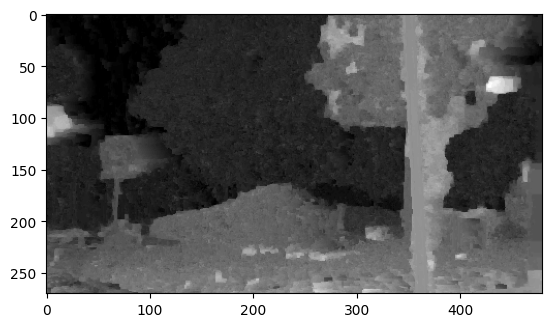

```python
labels= gco.cut_grid_graph_simple(
     100*differences,0.5*one_d_topology,
    n_iter=-1,
    algorithm='swap'

)

plt.imshow(labels.reshape(H,W),cmap='gray')
```

```python
labels= gco.cut_grid_graph(
     100*differences,0.5*one_d_topology,

    n_iter=-1,
    algorithm='swap'

)

plt.imshow(labels.reshape(H,W),cmap='gray')
```

[output not shown]

```
0 129598 129599 1 129600
```

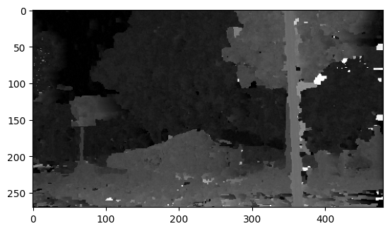

```python
labels= gco.cut_grid_graph(
     400*differences,50*rho,
    cost_v,
     cost_h,
     n_iter=-1,
    algorithm='swap'

)

plt.imshow(labels.reshape(H,W),cmap='gray')
```

```python
K2
```

```
array([[1.221227e+03, 0.000000e+00, 4.795000e+02],
       [0.000000e+00, 1.221227e+03, 2.695000e+02],
       [0.000000e+00, 0.000000e+00, 1.000000e+00]], dtype=float32)
```